# R Notebook

# Re-running code from lab as a starting point

```r
require(terra)
require(tidyterra)
require(sf)
require(adehabitatHR)
require(adehabitatLT)
require(adehabitatHS)
require(tidyverse)
require(survival)


#Import landcover tif
land = rast('https://github.com/ValenteJJ/SpatialEcology/raw/main/Week10/panther_landcover.tif')

#Reclassify the landcover tif
classification = read.table('https://raw.githubusercontent.com/ValenteJJ/SpatialEcology/main/Week10/landcover%20reclass.txt', header=T)
land = classify(land, classification[,c(1,3)])
land = categories(land, value=unique(classification[,c(3,4)]))


#Import panther locations
panthers = st_read('/vsicurl/https://github.com/ValenteJJ/SpatialEcology/raw/main/Week10/panthers.shp') %>%
  mutate(CatID = as.factor(CatID))

#Calculate wet forest focal statistic (5 km radius)
wetForest = land
values(wetForest) = 0
wetForest[land %in% c(10,12)] = 1
probMatrix = focalMat(wetForest, 5000, type='circle', fillNA=FALSE)
wetFocal = focal(wetForest, probMatrix, fun='sum', na.rm=T)


#Calculate dry forest focal statistic (5 km radius)
dryForest = land
values(dryForest) = 0
dryForest[land %in% c(11, 13)] = 1
probMatrix = focalMat(dryForest, 5000, type='circle', fillNA=FALSE)
dryFocal = focal(dryForest, probMatrix, fun='sum', na.rm=T)

#Stack together
layers = c(land, wetFocal, dryFocal)
names(layers) = c('landcover', 'wetForest', 'dryForest')

#Recreate our used points object
use = terra::extract(layers, panthers) %>%
  data.frame() %>%
  mutate(CatID = as.factor(panthers$CatID)) %>%
  group_by(CatID, landcover) %>%
  summarise(n = n()) %>%
  ungroup() %>%
  arrange(landcover) %>%
  pivot_wider(names_from = landcover, values_from = n, values_fill=0) %>%
  data.frame()
row.names(use) = use$CatID
use$CatID = NULL

#Recreate our available points object for a type II design
set.seed(8)
randII = spatSample(land, size=1000, as.points=T)
randIILand = data.frame(randII)

availII = randIILand %>%
  group_by(Description2) %>%
  summarise(n = n()) %>%
  ungroup() %>%
  rename(landcover = Description2) %>%
  filter(!(is.na(landcover) | landcover=='Exotics')) %>%
  pivot_wider(names_from = landcover, values_from = n)
```

# Challenge 1 (5 points)

In the lab, we estimated Manly’s statistic (wi) values for a type II study design. We also fit a logistic regression for a type II study design. For this challenge, you’re going to explore the relationship between wi values and beta values from a logistic regression model. Below I have recreated the analysis for producing wi values. I’ve also reconstructed the dataset we used for fitting the logistic regression models (allCovs).

Fit a new logistic regression model where use is a function of landcover-1 (the -1 removes the intercept from the fitted model). Make sure this is the only covariate in the model. Exponentiate the coefficients from the fitted model and compare them to the wi values calculated for each landcover type. What do you notice? Explain the similarities and/or differences in how you would interpret the wi values and exponentiated coefficients.

```r
#Recreating the wi analysis
selRatioII = widesII(u = use,
                     a = as.vector(as.matrix(availII)),
                     avknown = F,
                     alpha = 0.05)

#Recreating the dataset for logistic regression
useCovs = terra::extract(layers, panthers) %>%
  select(-ID) %>%
  mutate(use=1)
backCovs = terra::extract(layers, randII) %>%
  select(-ID) %>%
  mutate(use=0)
allCovs = rbind(useCovs, backCovs) %>%
  filter(!(is.na(landcover) | landcover=='Exotics')) %>%
  mutate(landcover = as.factor(as.character(landcover)))
```

```r
#New Model
model1 = glm(use ~ landcover-1, data=allCovs)

# Exponentiate the coefficients
exponentiated_coefficients <- exp(coef(model1))

# Display the exponentiated coefficients
print(exponentiated_coefficients)
```

```
          landcoverBarren   landcovercoastalwetland         landcoverCropland     landcoverCypressSwamp
                 1.842477                  1.135727                  1.294770                  2.300976
      landcoverDryprairie  landcoverFreshwatermarsh    landcoverHardwoodSwamp        landcoverOpenWater
                 1.699137                  1.558905                  2.169828                  1.097305
landcoverPastureGrassland         landcoverPineland      landcoverScrub/Shrub     landcoverUplandForest
                 1.444842                  2.070620                  1.710930                  2.098828
           landcoverUrban
                 1.074041
```

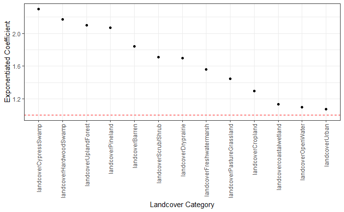

```r
# Convert to a data frame for plotting
coefficients_df <- data.frame(
  'category' = names(exponentiated_coefficients),
  'coefficient' = exponentiated_coefficients
)

####################################################################################
coefficients_df <- coefficients_df %>%
  arrange(desc(coefficient)) %>%
  mutate(category = factor(category, levels = category)) # Re-order factor levels

# Plotting the exponentiated coefficients
ggplot(coefficients_df, aes(x = category, y = coefficient)) +
  geom_point() +
  geom_hline(yintercept = 1, col = 'red', linetype = 'dashed') +
  theme_bw() +
  theme(axis.text.x = element_text(angle = 90, vjust = 0.5, hjust = 1)) +
  labs(y = "Exponentiated Coefficient", x = "Landcover Category")
```

```r
#wi values
selRatioII$wi
```

```
  coastalwetland         Cropland        OpenWater PastureGrassland            Urban           Barren
      0.15360566       0.36687836       0.10781769       0.61331156       0.08102276       1.65517932
      Dryprairie  Freshwatermarsh      Scrub.Shrub     CypressSwamp         Pineland    HardwoodSwamp
      1.18833387       0.84106466       1.22182328       5.26647966       2.81695424       3.62070477
    UplandForest
      3.01944834
```

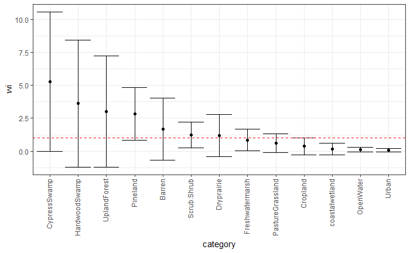

```r
tmp = data.frame('category' = names(selRatioII$wi),
                 'wi' = selRatioII$wi,
                 'ucl' = selRatioII$ICwiupper,
                 'lcl' = selRatioII$ICwilower) %>%
  arrange(desc(wi)) %>%
  mutate(category = factor(as.character(category), levels=category)) #This line is necessary to re-order the factor levels so that they are plotted in descending order of wi

ggplot(tmp, aes(x=category, y=wi))+
  geom_point()+
  geom_errorbar(aes(ymin=lcl, ymax=ucl))+
  geom_hline(yintercept=1, col='red', linetype='dashed')+
  theme_bw()+
  theme(axis.text.x = element_text(angle=90, vjust=0.3, hjust=1))
```

# Challenge 2 (5 points)

In the lab, we used the distribution of step lengths and turning angles to help us devise potential steps each individual could have taken at each point in time. Instead of step lengths, build a histogram representing the distribution of step speeds in km/hr. When and why might you choose to sample from a distribution of step speeds to calculate potential step lengths rather than drawing from the distribution of step lengths itself?

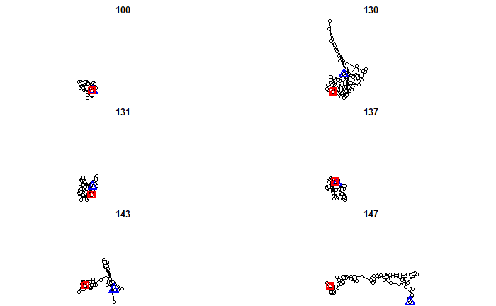

```r
# This function helps us tease out the date from the recorded DOY
substrRight = function(x, n){
  substr(x, nchar(x) - n+1, nchar(x))
}

#Here we're just creating a spatial object from our panthers sf object. Most of the code is dedicated to converting the DOY information to a real date.
panthersSp = panthers %>%
  mutate(Juldate = as.character(Juldate)) %>%
  mutate(date = as.numeric(substrRight(Juldate, 3))) %>%
  mutate(Date = as.Date(date, origin=as.Date("2006-01-01"))) %>%
  mutate(Date = as.POSIXct(Date, "%Y-%m-%d", tz='')) %>%
  as('Spatial')

#And this creates a trajectory object from the x-y coordinates and associated timestamps.
pantherLtraj = as.ltraj(xy=coordinates(panthersSp), date=panthersSp$Date, id=panthersSp$CatID, typeII=T)

plot(pantherLtraj)
```

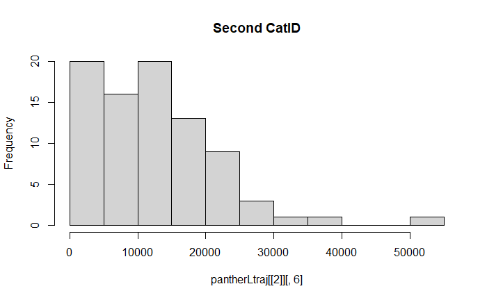

```r
hist(pantherLtraj[[2]][,6], main='Second CatID') # Example of step-length from Lab
```

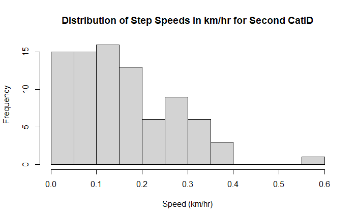

```r
####################################################################################

# Extract the relevant data for the second CatID
second_cat_data <- pantherLtraj[[2]]

# if dt is difference in time, dist is in meters, and dt is in seconds
speeds_km_hr <- (second_cat_data[, "dist"]/1000) / (second_cat_data[, "dt"]/3600) #if dt =

# Plot the histogram of speeds
hist(speeds_km_hr, main = "Distribution of Step Speeds in km/hr for Second CatID", xlab = "Speed (km/hr)")
```

```r
NA
NA
```

# Challenge 3 (5 points)

Path straightness is a metric we can use to evaluate how tortuous of a path a tracked animal took from one point to another. We calculate straightness as the straight line distance between two points divided by the length of the path actually taken. The resulting straightness statistic takes a value between 0 and 1 where 1 indicates a straight line path and 0 represents an infinitely tortuous path.

For each of the 6 panthers, calculate the straightness of the path between the first and last point recorded. To do that, first calculate the numerator for each panther as the straight-line distance between the start and end points. HINT: the coordinates for each point are in UTMs (meters from the Equator and meters from the Prime Meridian). With the x and y coordinates for two different points, you can calculate their straight-line distance using the Pythagorean theorem.

Next calculate the denominator for each panther. To do this, you can simply sum all of the step distances for that particular individual.

Now divide the numerator by the denominator. Which panther took the most tortuous path? Which took the least tortuous path?

[figure not shown]

# Challenge 4 (5 points)

For each panther, calculate the frequency with which locations were recorded as points per day. Plot path straightness as a function of frequency (there should be 6 points on this figure, one per panther). What relationship do you notice between these two variables, and why might that pattern be occurring?

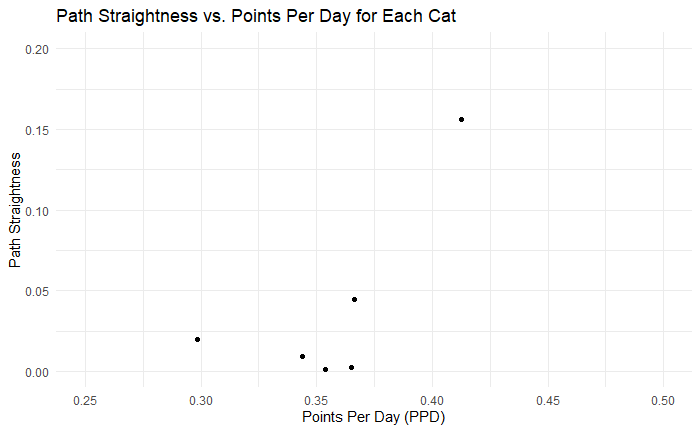

```r
# Calculate total span of days that passed
cat1days_difference <- as.numeric(first_cat_data$date[length(first_cat_data$date)] - first_cat_data$date[1])
cat2days_difference <- as.numeric(second_cat_data$date[length(second_cat_data$date)] - second_cat_data$date[1])
cat3days_difference <- as.numeric(third_cat_data$date[length(third_cat_data$date)] - third_cat_data$date[1])
cat4days_difference <- as.numeric(fourth_cat_data$date[length(fourth_cat_data$date)] - fourth_cat_data$date[1])
cat5days_difference <- as.numeric(fifth_cat_data$date[length(fifth_cat_data$date)] - fifth_cat_data$date[1])
cat6days_difference <- as.numeric(sixth_cat_data$date[length(sixth_cat_data$date)] - sixth_cat_data$date[1])

# Calculate Points Per Day
c1ppd <- (length(first_cat_data$date))/cat1days_difference
c2ppd <- (length(second_cat_data$date))/cat2days_difference
c3ppd <- (length(third_cat_data$date))/cat3days_difference
c4ppd <- (length(fourth_cat_data$date))/cat4days_difference
c5ppd <- (length(fifth_cat_data$date))/cat5days_difference
c6ppd <- (length(sixth_cat_data$date))/cat6days_difference

###########################################################################

# Assuming catXstraightness values and cXppd values have been previously calculated
data <- data.frame(
  CatID = factor(c("Cat 1", "Cat 2", "Cat 3", "Cat 4", "Cat 5", "Cat 6")),
  Straightness = c(cat1straightness, cat2straightness, cat3straightness, cat4straightness, cat5straightness, cat6straightness),
  PPD = c(c1ppd, c2ppd, c3ppd, c4ppd, c5ppd, c6ppd)
)

# Plotting path straightness as a function of points per day without labels
ggplot(data, aes(x = PPD, y = Straightness)) +
  geom_point() +
  theme_minimal() +
  labs(title = "Path Straightness vs. Points Per Day for Each Cat",
       x = "Points Per Day",
       y = "Path Straightness") +
  scale_x_continuous(name = "Points Per Day (PPD)", limits = c(0.25, 0.5)) +
  scale_y_continuous(name = "Path Straightness", limits = c(0, 0.2))  # Adjust the limits if necessary based on your data
```

[output not shown]

```r
NA
NA
NA
NA
NA
NA
```